# Introduction to robust control, $H_\infty$ methods

## MEC 560: Advanced control systems

### Vivek Yadav, PhD

### Overview

- \( H*2\) and $H*\infty $ norms
- Objective of $H_\infty $ control

*Note: $H_\infty $ control requires Robust Control ToolBox, which unfortunately is not available in MATLAB's student version*

- Details on implementation of $H_\infty $ control algorithm can be found https://ocw.mit.edu/courses/electrical-engineering-and-computer-science/6-245-multivariable-control-systems-spring-2004/lecture-notes/lec7_6245_2004.pdf

### Computing \(H_2 \) norm

Consider the system given by, $$ \dot{X} = A X + B w $$

The laplace transform of

$$ \dot{X} = A X + B w $$

is

$$ s X(s) = A X(s) + B w(s) $$

rearranging gives,

$$ X(s) = ( sI - A )^{-1}Bw(s) $$

Therefore, the laplace transform of performance measure is,

$$ e(s) = \left( C ( sI - A )^{-1}B + D \right) w(s) $$

Therefore, the transfer function relating the disturbance \( w \) and the performance measure $ e_{cl}$ is,

$$G(s) = \frac{e(s)}{w(s)} = \left( C( sI - A)^{-1}B + D \right) $$$$ || G ||_{H_2}^2 = \frac{1}{2 \pi} \int_{-\infty}^{\infty} || G(e^{j\omega})||_F^2 d \omega $$

### $H_{\infty}$ norm

- it is possible that the true magnitude never goes to zero, therefore the integral above can go to infinity.
- $H_{\infty}$ norm is the maximum value of the frequency response of the transfer function.
- As this maximum occurs at a fixed value, (either 0 or at resonance frequency), therefore is easier to compute.

### \(H*2\) and $ H*{\infty}$ norm example

Consider the system given by,

$$ \ddot{x} + \dot{x} + 2x = w $$

with performance measure \( e = X \).

The transfer function between \(X \) and \( w \) is,

$$ G(s) = \frac{1}{s^2 + s + 2} $$

Therefore, the frequency response can be computed as,

$$ G(j\omega) = \frac{1}{(j\omega)^2 + j\omega + 2} $$

```matlab
clc
close all
clear all

w = 0:0.01:100;

% define transfer function
G_sys = @(s)(1/(s^2+s+2));

for i_w = 1:length(w)
    % for complex numbers, abs gives magnitude
    G_jw(i_w ) = abs(G_sys(j*w(i_w)));
end

% H2_norm is area under the curve
H2_norm = 1/2/pi*trapz(G_jw);
```

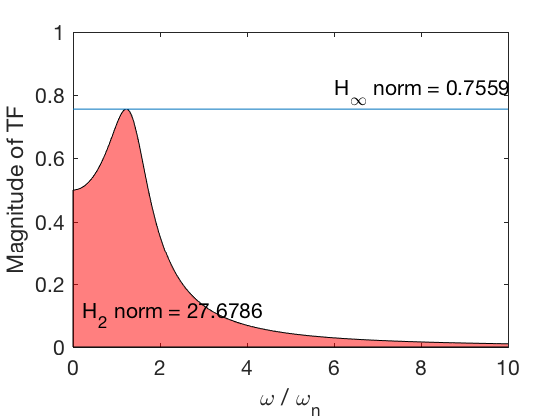

```matlab
figure;
plot(w,G_jw,'k')
hold on
a = area(w,G_jw);
a.FaceColor='r';
a.FaceAlpha = 0.5;
axis([0 10 0 1])
plot([0,10],[max(G_jw),max(G_jw)])
text(6,1.08*max(G_jw),['H_{\infty} norm = ' num2str(max(G_jw))])
text(.2,.1,['H_2 norm = ' num2str(H2_norm)])
ylabel('Magnitude of TF')
xlabel('\omega / \omega_n')
```

```matlab
clc
close all
clear all

H = tf([1],[1 1 2]);
w = 0:0.01:100;

[mag,ph,w,sdmag,sdphase] = bode(H,w);
G_jw = squeeze(mag);
% H2_norm is area under the curve
H2_norm = 1/2/pi*trapz(G_jw);
```

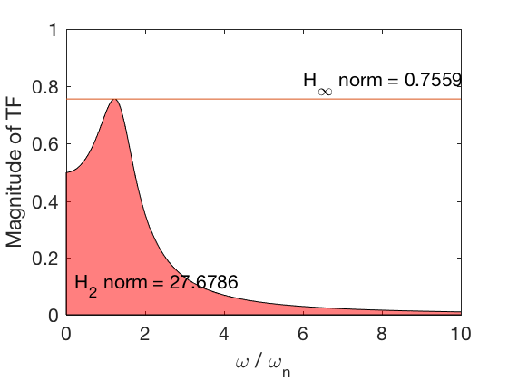

```matlab
figure;
plot(w,G_jw)
hold on
a = area(w,G_jw);
a.FaceColor='r';
a.FaceAlpha = 0.5;
axis([0 10 0 1])
plot([0,10],[max(G_jw),max(G_jw)])
text(6,1.08*max(G_jw),['H_{\infty} norm = ' num2str(max(G_jw))])
text(.2,.1,['H_2 norm = ' num2str(H2_norm)])
ylabel('Magnitude of TF')
xlabel('\omega / \omega_n')
```

### $ H_{\infty}$ vs \( H_2 \) criteria

$ H_{\infty}$ and \( H_2 \) criteria both reflect the sensitivity of the system to applied perturbation, however, there is subtle difference between the two, and depending on application one form may be better than the other.

1. \( H*2 \) norm is smoother than the $H*\infty$ with respect to model parameters, therefore, if one is interested in system identification applications, \( H_2 \) norm is better suited.
2. In control, \( H*2 \) norm is typically larger than $H*\infty$ norm

Note, in the special case when the performance crietria is the entire state-space ( \( C_1 = I \) ), then the \( H_2 \) control becomes Linear Quadratic control and the observer becomes linear quadratic estimator. This is the reason why somethimes Linear Quadratic Gaussian control scheme is also referred as \( H_2 \)-optimal control.

### $H_\infty$ control algorithm (not on course).

Consider the system given below,

$$ \dot{X} = AX + B_1 w + B_2 u $$

with measurements,

$$ y = C_2 X + D_{21} w $$

and performance measure given by,

$$ e = C_1 X + D_{11}w+ D_{12} u $$

### $H_\infty$ control algorithm .

In $H_2$ (or $H_\infty $) control, the control-observer set is defined by another dynamic system given by,

$$ \dot{X}_{f} = A_fX_{f} + B_f y $$

$$ u = C_f X_f + D_f y $$

The objective is to design \(A_f\), \(B_f\), \(C_f\) and \(D_f\) such that the resulting closed loop system in terms of states \( [X,X_f ] \) and input \( w \) is stable (has negative eigen values) and insensitive to changes in \( w \). In other words, we wish to apply a control that minimizes the sensitivity of the system to the perturbation \( w \).